# SmartMess Analysis

# Bookings by Department

```python
department_booking =(
     booking_full[booking_full['status'].isin(['Booked', 'Transferred_In'])]
    .groupby(['department'])
    .size()
    .reset_index(name='count')
)
print(department_booking)
```

```
  department  count
0         CE   6134
1        CSE   5877
2        ECE   5817
3         EE   6618
4         ME   6484
```

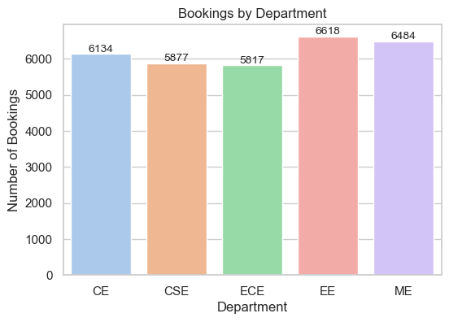

```python
plt.figure(figsize=(6,4))
ax = sns.barplot(data=department_booking, x="department", y="count", hue="department", palette="pastel", legend=False)

for p in ax.patches:
    ax.annotate(str(int(p.get_height())),
                (p.get_x() + p.get_width() / 2, p.get_height()),
                ha = 'center', va='bottom', fontsize=10)
plt.title("Bookings by Department")
plt.xlabel("Department")
plt.ylabel("Number of Bookings")
plt.show()
```

# Gender Distribution

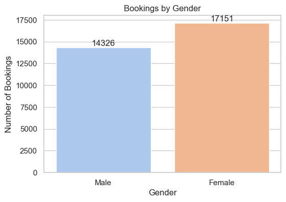

```python
plt.figure(figsize=(6,4))
ax = sns.countplot(data=booking_full, x="gender",  hue="gender", palette="pastel", legend=False)

for p in ax.patches:
    ax.annotate(str(int(p.get_height())),
                (p.get_x() + p.get_width() / 2, p.get_height()),
                ha = 'center', va='bottom')
plt.title("Bookings by Gender")
plt.xlabel("Gender")
plt.ylabel("Number of Bookings")
plt.show()
```

# Daily Bookings Trend

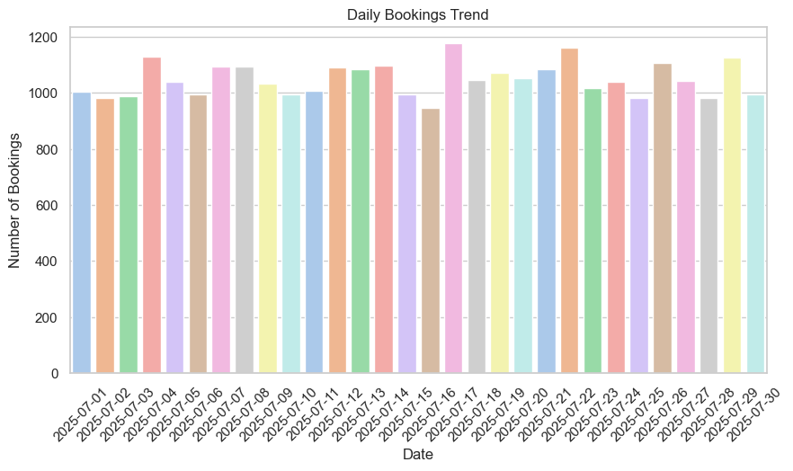

```python
plt.figure(figsize=(10,5))
sns.countplot(data=booking_full, x="date", hue="date", palette="pastel", legend=False)
plt.title("Daily Bookings Trend")
plt.xlabel("Date")
plt.ylabel("Number of Bookings")
plt.xticks(rotation=45)
plt.show()
```

# Gender-wise Patterns

```python
gender_counts = (
     booking_full[booking_full['status'].isin(['Booked', 'Transferred_In'])]
    .groupby(['gender'])
    .size()
    .reset_index(name='count')
)
print(gender_counts)
```

```
   gender  count
0  Female  16842
1    Male  14088
```

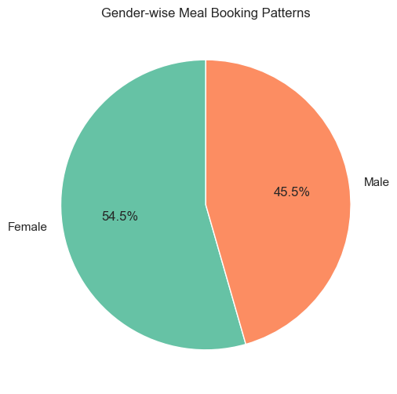

```python
plt.figure(figsize=(6,6))
plt.pie(gender_counts["count"], labels=gender_counts["gender"], autopct='%1.1f%%', startangle=90, colors=sns.color_palette("Set2"))
plt.title("Gender-wise Meal Booking Patterns")
plt.show()
```

# Average Number of Bookings per Day per Meal

```python
booking_full['day'] = booking_full['booked_at'].dt.day_name()
print(booking_full)
```

```
       user_id  meal_type_id       date  status  booked_at  is_special_order  \
0           41             1 2025-07-01  Booked 2025-07-01             False
1           34             1 2025-07-01  Booked 2025-07-01             False
2          486             1 2025-07-01  Booked 2025-07-01             False
3          362             1 2025-07-01  Booked 2025-07-01             False
4          458             1 2025-07-01  Booked 2025-07-01             False
...        ...           ...        ...     ...        ...               ...
31472      462             3 2025-07-30  Booked 2025-07-30             False
31473       60             3 2025-07-30  Booked 2025-07-30             False
31474      562             3 2025-07-30  Booked 2025-07-30              True
31475      145             3 2025-07-30  Booked 2025-07-30              True
31476      760             3 2025-07-30  Booked 2025-07-30              True

          name    rollnumber department  gender  \
0        Omkar  NITW21CSE040         CE    Male
```

[output cut: 38 more lines]

```python
daily_counts = booking_full.groupby(['date', 'name_of_meal','day']).size().reset_index(name='bookings')
print(daily_counts)
```

```
         date name_of_meal        day  bookings
0  2025-07-01    Breakfast    Tuesday       350
1  2025-07-01       Dinner    Tuesday       323
2  2025-07-01        Lunch    Tuesday       332
3  2025-07-02    Breakfast  Wednesday       305
4  2025-07-02       Dinner  Wednesday       311
..        ...          ...        ...       ...
85 2025-07-29       Dinner    Tuesday       379
86 2025-07-29        Lunch    Tuesday       396
87 2025-07-30    Breakfast  Wednesday       317
88 2025-07-30       Dinner  Wednesday       371
89 2025-07-30        Lunch  Wednesday       308

[90 rows x 4 columns]
```

```python
avg_bookings = daily_counts.groupby(['name_of_meal','day'])['bookings'].mean().reset_index()

print(avg_bookings)
```

```
   name_of_meal        day  bookings
0     Breakfast     Friday    347.50
1     Breakfast     Monday    357.50
2     Breakfast   Saturday    350.75
3     Breakfast     Sunday    354.00
4     Breakfast   Thursday    337.25
5     Breakfast    Tuesday    358.80
6     Breakfast  Wednesday    321.60
7        Dinner     Friday    353.50
8        Dinner     Monday    357.75
9        Dinner   Saturday    377.25
10       Dinner     Sunday    343.25
11       Dinner   Thursday    361.25
12       Dinner    Tuesday    356.40
13       Dinner  Wednesday    331.40
14        Lunch     Friday    340.25
15        Lunch     Monday    349.50
16        Lunch   Saturday    350.25
17        Lunch     Sunday    347.00
18        Lunch   Thursday    351.75
19        Lunch    Tuesday    361.80
20        Lunch  Wednesday    342.40
```

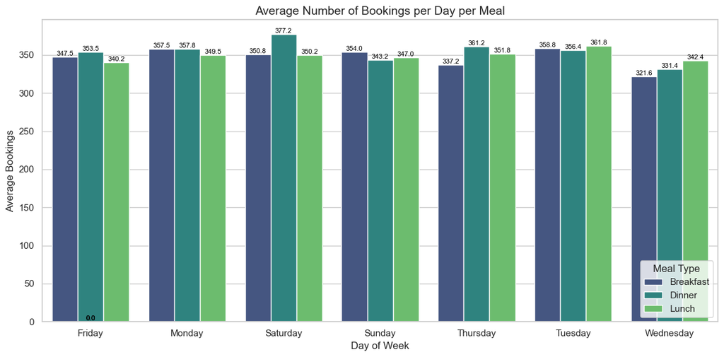

```python
plt.figure(figsize=(12,6))
ax = sns.barplot(
    data=avg_bookings,
    x='day', y='bookings', hue='name_of_meal',
    palette='viridis'
)

for p in ax.patches:
    ax.annotate(f"{p.get_height():.1f}",
                (p.get_x() + p.get_width() / 2., p.get_height()),
                ha='center', va='bottom', fontsize=8, color='black', rotation=0)

plt.title("Average Number of Bookings per Day per Meal", fontsize=14)
plt.ylabel("Average Bookings")
plt.xlabel("Day of Week")
plt.legend(title="Meal Type")
plt.tight_layout()
plt.show()
```

# Meal bookings clearly follow weekly patterns, Tuesdays showing higher demand and Wednesdays consistently lower. By aligning food preparation and resources with these patterns, it is possible to reduce waste, meet student needs more effectively, and ensure smoother dining operations.

# Heatmap: Day of Week vs Meal Type

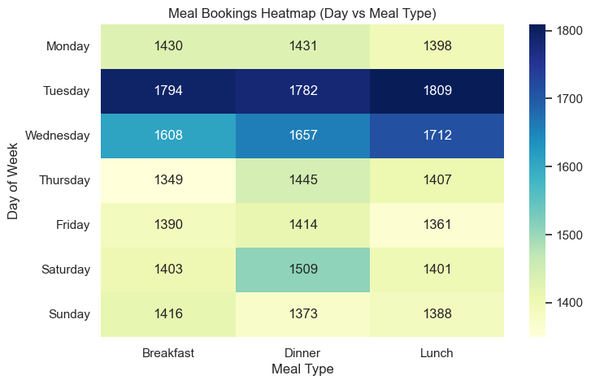

```python
heatmap_data = booking_full.groupby(["day", "name_of_meal"]).size().reset_index(name="count")
heatmap_pivot = heatmap_data.pivot(index="day", columns="name_of_meal", values="count")

weekday_order = ["Monday","Tuesday","Wednesday","Thursday","Friday","Saturday","Sunday"]
heatmap_pivot = heatmap_pivot.reindex(weekday_order)

plt.figure(figsize=(8,5))
sns.heatmap(heatmap_pivot, annot=True, fmt="d", cmap="YlGnBu")
plt.title("Meal Bookings Heatmap (Day vs Meal Type)")
plt.xlabel("Meal Type")
plt.ylabel("Day of Week")
plt.show()
```

# Cancellation % per meal

```python
meal_cancel = booking_full.groupby(['name_of_meal', 'status']).size().reset_index(name='count')
print(meal_cancel)
```

```
   name_of_meal           status  count
0     Breakfast           Booked  10166
1     Breakfast         Canceled    160
2     Breakfast   Transferred_In     32
3     Breakfast  Transferred_Out     32
4        Dinner           Booked  10381
5        Dinner         Canceled    144
6        Dinner   Transferred_In     43
7        Dinner  Transferred_Out     43
8         Lunch           Booked  10281
9         Lunch         Canceled    141
10        Lunch   Transferred_In     27
11        Lunch  Transferred_Out     27
```

```python
meal_total = (booking_full[booking_full['status'].isin(['Booked','Canceled','Transferred_In'])]
              .groupby('name_of_meal').size().reset_index(name='total'))
print(meal_total)
```

```
  name_of_meal  total
0    Breakfast  10358
1       Dinner  10568
2        Lunch  10449
```

```python
meal_cancel = pd.merge(meal_cancel, meal_total, on="name_of_meal")
print(meal_cancel)
```

```
   name_of_meal           status  count  total
0     Breakfast           Booked  10166  10358
1     Breakfast         Canceled    160  10358
2     Breakfast   Transferred_In     32  10358
3     Breakfast  Transferred_Out     32  10358
4        Dinner           Booked  10381  10568
5        Dinner         Canceled    144  10568
6        Dinner   Transferred_In     43  10568
7        Dinner  Transferred_Out     43  10568
8         Lunch           Booked  10281  10449
9         Lunch         Canceled    141  10449
10        Lunch   Transferred_In     27  10449
11        Lunch  Transferred_Out     27  10449
```

```python
meal_cancel['cancel_pct'] = (meal_cancel['count'] / meal_cancel['total']) * 100
print(meal_cancel)
```

```
   name_of_meal           status  count  total  cancel_pct
0     Breakfast           Booked  10166  10358   98.146360
1     Breakfast         Canceled    160  10358    1.544700
2     Breakfast   Transferred_In     32  10358    0.308940
3     Breakfast  Transferred_Out     32  10358    0.308940
4        Dinner           Booked  10381  10568   98.230507
5        Dinner         Canceled    144  10568    1.362604
6        Dinner   Transferred_In     43  10568    0.406889
7        Dinner  Transferred_Out     43  10568    0.406889
8         Lunch           Booked  10281  10449   98.392191
9         Lunch         Canceled    141  10449    1.349411
10        Lunch   Transferred_In     27  10449    0.258398
11        Lunch  Transferred_Out     27  10449    0.258398
```

```python
cancel_data = meal_cancel[meal_cancel['status'].str.lower() == 'canceled']

print(cancel_data)
```

```
  name_of_meal    status  count  total  cancel_pct
1    Breakfast  Canceled    160  10358    1.544700
5       Dinner  Canceled    144  10568    1.362604
9        Lunch  Canceled    141  10449    1.349411
```

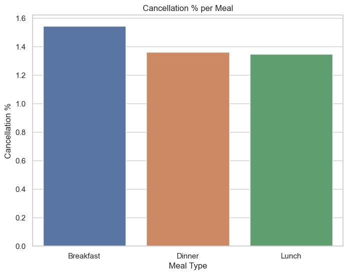

```python
plt.figure(figsize=(8,6))
sns.barplot(data=cancel_data,
            x="name_of_meal", y="cancel_pct", hue="name_of_meal", legend=False)
plt.title("Cancellation % per Meal")
plt.ylabel("Cancellation %")
plt.xlabel("Meal Type")
plt.show()
```

# Wallet balance change tracking

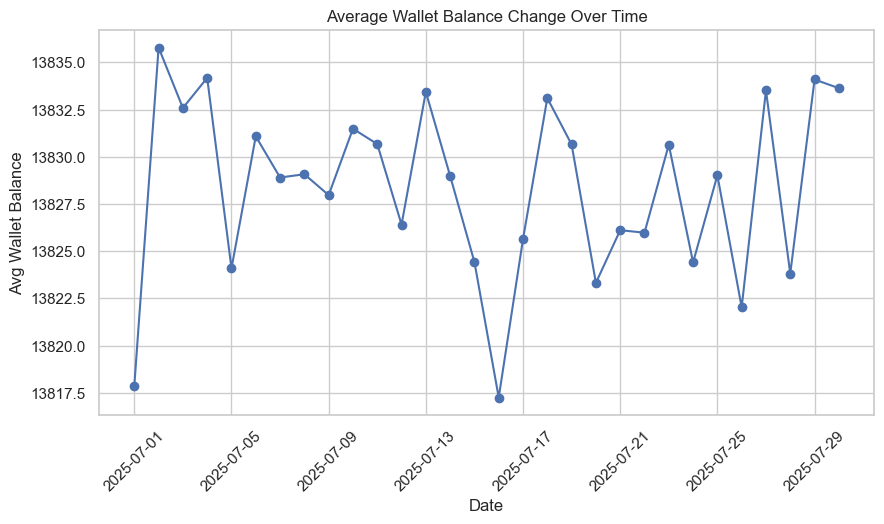

```python
wallet_trend = booking_full.groupby('date')['refund_wallet'].mean().reset_index()

plt.figure(figsize=(10,5))
plt.plot(wallet_trend['date'], wallet_trend['refund_wallet'], marker='o')
plt.title("Average Wallet Balance Change Over Time")
plt.xlabel("Date")
plt.ylabel("Avg Wallet Balance")
plt.xticks(rotation=45)
plt.show()
```

# Stacked bar chart: Booked vs Cancelled

```python
meal_status = booking_full.groupby(['date','status']).size().unstack(fill_value=0)
print(meal_status)
```

```
status      Booked  Canceled  Transferred_In  Transferred_Out
date
2025-07-01     980        11               7                7
2025-07-02     964        15               2                2
2025-07-03     964        18               4                4
2025-07-04    1117        10               2                2
2025-07-05    1014        19               4                4
2025-07-06     969        18               4                4
2025-07-07    1079        14               1                1
2025-07-08    1075        19               0                0
2025-07-09    1012        19               2                2
2025-07-10     974        13               4                4
2025-07-11     979        17               6                6
2025-07-12    1073        12               4                4
2025-07-13    1063        10               6                6
2025-07-14    1074        19               2                2
2025-07-15     973        13               5                5
2025-07-16     930        16               0                0
2025-07-17    1154        15               4                4
2025-07-18    1019        18               4                4
2025-07-19    1046        19               3                3
2025-07-20    1033        14               3                3
2025-07-21    1064        12               5                5
2025-07-22    1143        13               3                3
2025-07-23    1004        13               0                0
2025-07-24    1014        17               4                4
2025-07-25     970        11               0                0
2025-07-26    1084        18               3                3
2025-07-27    1019        15               5                5
2025-07-28     959        10               6                6
2025-07-29    1105        15               4                4
2025-07-30     974        12               5                5
```

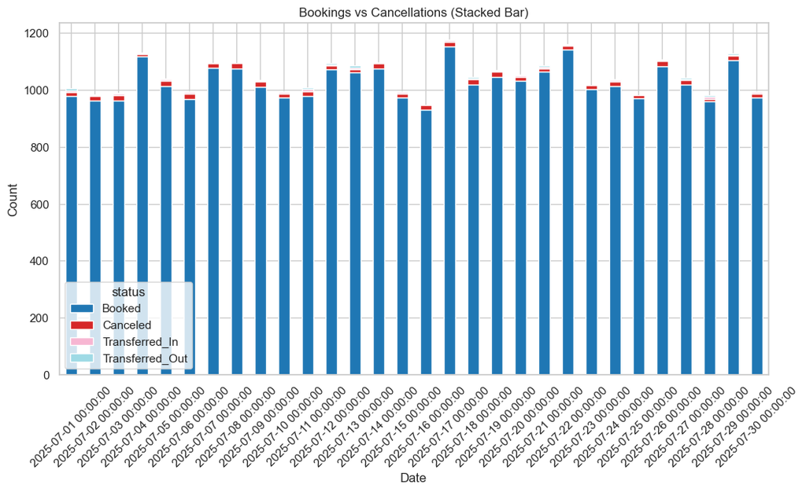

```python
meal_status = booking_full.groupby(['date','status']).size().unstack(fill_value=0)

meal_status.plot(kind='bar', stacked=True, figsize=(12,6), colormap="tab20")
plt.title("Bookings vs Cancellations (Stacked Bar)")
plt.xlabel("Date")
plt.ylabel("Count")
plt.xticks(rotation=45)
plt.show()
```

# Analysis of Average Available Slots per Day of the Week by Meal Type

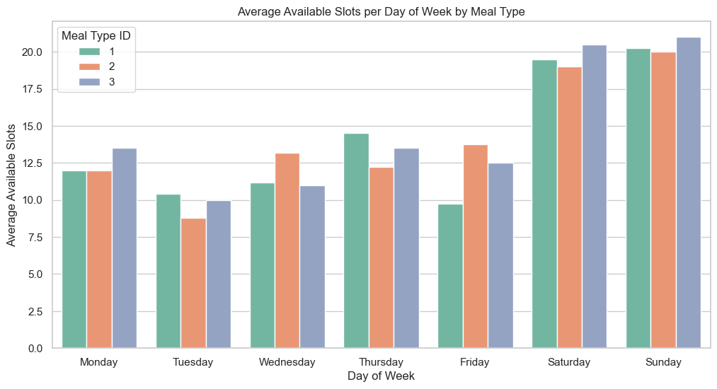

```python
special_df["date"] = pd.to_datetime(special_df["date"], format="%d-%m-%Y")

special_df["day_name"] = special_df["date"].dt.day_name()

avg_slots = (
    special_df.groupby(["day_name", "meal_type_id"])["available_slots"]
    .mean()
    .reset_index()
)

day_order = ["Monday", "Tuesday", "Wednesday", "Thursday", "Friday", "Saturday", "Sunday"]
avg_slots["day_name"] = pd.Categorical(avg_slots["day_name"], categories=day_order, ordered=True)

plt.figure(figsize=(12,6))
sns.barplot(
    data=avg_slots,
    x="day_name",
    y="available_slots",
    hue="meal_type_id",
    palette="Set2"
)

plt.xlabel("Day of Week")
plt.ylabel("Average Available Slots")
plt.title("Average Available Slots per Day of Week by Meal Type")
plt.legend(title="Meal Type ID")
plt.show()
```

# The analysis shows that Sunday has the highest average availability (20.4 slots) while Tuesday records the lowest (9.7 slots). On average, providing around 14 special orders per day would balance the overall demand effectively.

# this project provided valuable insights into student meal booking and special order patterns, enabling better management of resources. By analyzing the data, we identified meaningful trends that can help improve efficiency and decision-making for future operations.